# Introduction-Python-Pandas-Networks

### What about a network picture of the flights?

```python
import networkx as nx
```

```python
flight_graph = nx.DiGraph()
```

```python
pos_dict = {}
for row in lat_long[lat_long[4] == 'USA'].iterrows():
    airport_code = row[1][1]
    flight_graph.add_node(airport_code)
    pos_dict[airport_code] = (row[1][15], row[1][14])
```

```python
source_airport = 'SFO'
destinations = flights_in_US[(flights_in_US.ORIGIN == source_airport) &
              (flights_in_US.YEAR == 2015)].DEST.unique()
```

```python
for destination in destinations:
    if destination in pos_dict:
        flight_graph.add_edge(source_airport, destination)
```

[figure not shown]

```python
nx.draw(flight_graph)
```

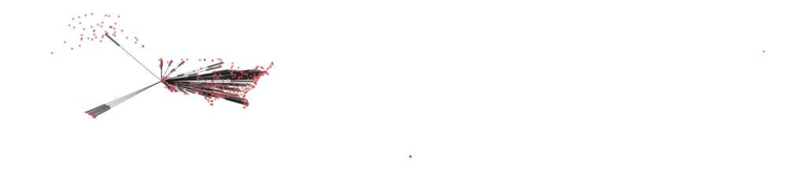

```python
plt.figure(figsize=(20, 4))
nx.draw(flight_graph, pos=pos_dict, node_size=10, alpha=0.5)
```

### Top travel destinations?

```python
flights_in_US[flights_in_US.YEAR == 1990].PASSENGERS.idxmax()
```

```
3917
```

```python
flights_in_US.iloc[3917]
```

```
YEAR                                                                1990
ORIGIN                                                               LAX
DEST                                                                 HNL
UNIQUE_CARRIER_NAME    {'Heavylift Cargo Airlines Lt', 'Hawaiian Airl...
PASSENGERS                                                   1.82716e+06
Name: 3917, dtype: object
```

```python
flights_in_US[(flights_in_US.ORIGIN == 'LAX') & (flights_in_US.DEST == 'HNL')]
```

|  | YEAR | ORIGIN | DEST | UNIQUE_CARRIER_NAME | PASSENGERS |
| --- | --- | --- | --- | --- | --- |
| 3917 | 1990 | LAX | HNL | {'Heavylift Cargo Airlines Lt', 'Hawaiian Airl... | 1827164.0 |
| 11810 | 1991 | LAX | HNL | {'Hawaiian Airlines Inc.', 'Delta Air Lines In... | 1828453.0 |
| 19632 | 1992 | LAX | HNL | {'America West Airlines Inc.', 'Hawaiian Airli... | 1732270.0 |
| 27410 | 1993 | LAX | HNL | {'Express One International Inc.', 'Hawaiian A... | 1826148.0 |
| 35235 | 1994 | LAX | HNL | {'Express One International Inc.', 'Hawaiian A... | 1696143.0 |
| 43472 | 1995 | LAX | HNL | {'Hawaiian Airlines Inc.', 'Continental Micron... | 1715915.0 |
| 52495 | 1996 | LAX | HNL | {'Hawaiian Airlines Inc.', 'Delta Air Lines In... | 1664672.0 |
| 61730 | 1997 | LAX | HNL | {'Hawaiian Airlines Inc.', 'Delta Air Lines In... | 1597944.0 |
| 70739 | 1998 | LAX | HNL | {'Hawaiian Airlines Inc.', 'Delta Air Lines In... | 1456153.0 |
| 80086 | 1999 | LAX | HNL | {'Heavylift Cargo Airlines Lt', 'Hawaiian Airl... | 1409678.0 |
| 90435 | 2000 | LAX | HNL | {'Hawaiian Airlines Inc.', 'Delta Air Lines In... | 1462597.0 |
| 101838 | 2001 | LAX | HNL | {'Hawaiian Airlines Inc.', 'Delta Air Lines In... | 1361228.0 |
| 118082 | 2002 | LAX | HNL | {'Federal Express Corporation', 'Hawaiian Airl... | 1395797.0 |
| 140159 | 2003 | LAX | HNL | {'Federal Express Corporation', 'Hawaiian Airl... | 1226091.0 |
| 165434 | 2004 | LAX | HNL | {'Federal Express Corporation', 'Hawaiian Airl... | 1240272.0 |
| 191679 | 2005 | LAX | HNL | {'Federal Express Corporation', 'Hawaiian Airl... | 1271700.0 |
| 217069 | 2006 | LAX | HNL | {'Federal Express Corporation', 'Hawaiian Airl... | 1107015.0 |
| 243328 | 2007 | LAX | HNL | {'Federal Express Corporation', 'Hawaiian Airl... | 1142267.0 |
| 270343 | 2008 | LAX | HNL | {'Federal Express Corporation', 'Hawaiian Airl... | 1026419.0 |
| 296041 | 2009 | LAX | HNL | {'Federal Express Corporation', 'Hawaiian Airl... | 976228.0 |
| 321265 | 2010 | LAX | HNL | {'Federal Express Corporation', 'Hawaiian Airl... | 1009671.0 |
| 346789 | 2011 | LAX | HNL | {'Federal Express Corporation', 'Hawaiian Airl... | 1080653.0 |
| 371644 | 2012 | LAX | HNL | {'Federal Express Corporation', 'Hawaiian Airl... | 1050588.0 |
| 395899 | 2013 | LAX | HNL | {'Federal Express Corporation', 'Hawaiian Airl... | 1062594.0 |
| 420469 | 2014 | LAX | HNL | {'Federal Express Corporation', 'Hawaiian Airl... | 1123975.0 |
| 445889 | 2015 | LAX | HNL | {'Federal Express Corporation', 'Hawaiian Airl... | 1115732.0 |

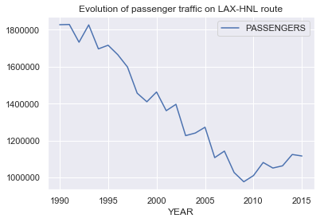

```python
flights_in_US[(flights_in_US.ORIGIN == 'LAX') & (flights_in_US.DEST == 'HNL')].plot(
    x='YEAR', y='PASSENGERS', title='Evolution of passenger traffic on LAX-HNL route')
```

```python
flights_in_US[flights_in_US.YEAR == 2015].PASSENGERS.idxmax()
```

```
445978
```

```python
flights_in_US.iloc[445978]
```

```
YEAR                                                                2015
ORIGIN                                                               LAX
DEST                                                                 SFO
UNIQUE_CARRIER_NAME    {'Hawaiian Airlines Inc.', 'Delta Air Lines In...
PASSENGERS                                                   1.86907e+06
Name: 445978, dtype: object
```

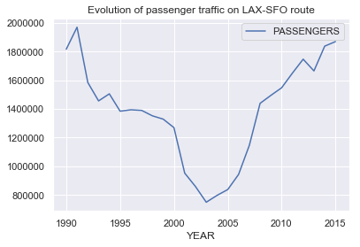

```python
flights_in_US[(flights_in_US.ORIGIN == 'LAX') & (flights_in_US.DEST == 'SFO')].plot(
    x='YEAR', y='PASSENGERS', title='Evolution of passenger traffic on LAX-SFO route')
```

### What about the total number of passengers?

```python
flights_in_US.groupby(['YEAR']).sum()
```

| YEAR | PASSENGERS |
| --- | --- |
| 1990 | 448862173.0 |
| 1991 | 434938145.0 |
| 1992 | 454342213.0 |
| 1993 | 464431692.0 |
| 1994 | 505298026.0 |
| 1995 | 519495497.0 |
| 1996 | 548286560.0 |
| 1997 | 564392466.0 |
| 1998 | 575354633.0 |
| 1999 | 597714868.0 |
| 2000 | 623049036.0 |
| 2001 | 580446827.0 |
| 2002 | 571912627.0 |
| 2003 | 604060205.0 |
| 2004 | 651179228.0 |
| 2005 | 676692491.0 |
| 2006 | 676812884.0 |
| 2007 | 698348181.0 |
| 2008 | 669749629.0 |
| 2009 | 634897818.0 |
| 2010 | 646481572.0 |
| 2011 | 656320870.0 |
| 2012 | 657645308.0 |
| 2013 | 660057640.0 |
| 2014 | 676358409.0 |
| 2015 | 707749086.0 |

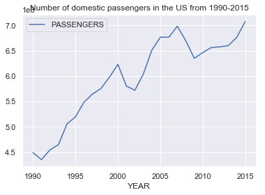

```python
flights_in_US.groupby(['YEAR']).sum().plot(title='Number of domestic passengers in the US from 1990-2015')
```

#### Monthly dataset exhibits seasonality as expected.

[figure not shown]

### Exercise

Plot the number of passengers from New York airports (JFK, EWR, LGA) to SFO, LAX, ORD from 1990-2015. (3 separate plots)

HINTS:

- to check if value belongs to a list in pandas, use `.isin()` function
- use `groupby` for summing the number of passengers.

(8 mins)

```python
list_of_new_york_airports = ['JFK', 'EWR', 'LGA']
```

```python
# %load sols/exercise3.py
```

### Let's change gears and talk about Game of thrones or shall I say Network of Thrones.

It is suprising right? What is the relationship between a fatansy TV show/novel and network science or python(it's not related to a dragon).

If you haven't heard of Game of Thrones, then you must be really good at hiding. Game of Thrones is the hugely popular television series by HBO based on the (also) hugely popular book series A Song of Ice and Fire by George R.R. Martin. In this notebook, we will analyze the co-occurrence network of the characters in the Game of Thrones books. Here, two characters are considered to co-occur if their names appear in the vicinity of 15 words from one another in the books.

Andrew J. Beveridge, an associate professor of mathematics at Macalester College, and Jie Shan, an undergraduate created a network from the book A Storm of Swords by extracting relationships between characters to find out the most important characters in the book(or GoT).

The dataset is publicly avaiable for the 5 books at https://github.com/mathbeveridge/asoiaf. This is an interaction network and were created by connecting two characters whenever their names (or nicknames) appeared within 15 words of one another in one of the books. The edge weight corresponds to the number of interactions.

Credits:

Blog: https://networkofthrones.wordpress.com

Math Horizons Article: https://www.maa.org/sites/default/files/pdf/Mathhorizons/NetworkofThrones%20%281%29.pdf

```python
import pandas as pd
import networkx as nx
import matplotlib.pyplot as plt
from matplotlib import cm
import community
import numpy as np
import warnings
warnings.filterwarnings('ignore')

%matplotlib inline
```

```python
book1 = pd.read_csv('data/asoiaf-book1-edges.csv')
book2 = pd.read_csv('data/asoiaf-book2-edges.csv')
book3 = pd.read_csv('data/asoiaf-book3-edges.csv')
book4 = pd.read_csv('data/asoiaf-book4-edges.csv')
book5 = pd.read_csv('data/asoiaf-book5-edges.csv')
```

```python
book1.head()
```

|  | Source | Target | Type | weight | book |
| --- | --- | --- | --- | --- | --- |
| 0 | Addam-Marbrand | Jaime-Lannister | Undirected | 3 | 1 |
| 1 | Addam-Marbrand | Tywin-Lannister | Undirected | 6 | 1 |
| 2 | Aegon-I-Targaryen | Daenerys-Targaryen | Undirected | 5 | 1 |
| 3 | Aegon-I-Targaryen | Eddard-Stark | Undirected | 4 | 1 |
| 4 | Aemon-Targaryen-(Maester-Aemon) | Alliser-Thorne | Undirected | 4 | 1 |

#### Which characters have the most presence in the books?

```python
book1.weight.sum()
```

```
7366
```

```python
book1.groupby(['Source'])['weight'].sum().head()
```

```
Source
Addam-Marbrand                      9
Aegon-I-Targaryen                   9
Aemon-Targaryen-(Maester-Aemon)    74
Aerys-II-Targaryen                 37
Aggo                               36
Name: weight, dtype: int64
```

```python
(book1.groupby(['Source'])['weight'].sum()/book1.weight.sum()).sort_values(ascending=False).head()
```

```
Source
Eddard-Stark          0.137524
Bran-Stark            0.069373
Catelyn-Stark         0.064485
Arya-Stark            0.058376
Daenerys-Targaryen    0.057019
Name: weight, dtype: float64
```

```python
(book5.groupby(['Source'])['weight'].sum()/book5.weight.sum()).sort_values(ascending=False).head()
```

```
Source
Daenerys-Targaryen    0.091084
Jon-Snow              0.084253
Barristan-Selmy       0.046768
Bran-Stark            0.026975
Cersei-Lannister      0.025223
Name: weight, dtype: float64
```

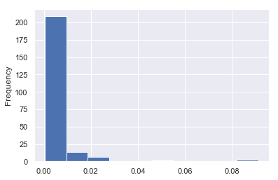

```python
(book5.groupby(['Source'])['weight'].sum()/book5.weight.sum()).sort_values(ascending=False).plot.hist()
```

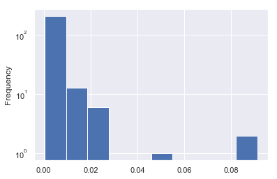

```python
(book5.groupby(['Source'])['weight'].sum()/book5.weight.sum()).sort_values(ascending=False).plot.hist(log=True)
```

##### Let's create a network to get a better picture of this dataset

```python
G_book1 = nx.Graph()
G_book2 = nx.Graph()
G_book3 = nx.Graph()
G_book4 = nx.Graph()
G_book5 = nx.Graph()
```

```python
G_book1
```

```
<networkx.classes.graph.Graph at 0x1239d6828>
```

```python
G_book1.nodes()
```

```
[]
```

```python
G_book1.edges()
```

```
[]
```

```python
for row in book1.iterrows():
    G_book1.add_edge(row[1]['Source'], row[1]['Target'], weight=row[1]['weight'], book=row[1]['book'])
```

```python
G_book1.nodes()[0:10]
```

```
['Addam-Marbrand',
 'Jaime-Lannister',
 'Tywin-Lannister',
 'Aegon-I-Targaryen',
 'Daenerys-Targaryen',
 'Eddard-Stark',
 'Aemon-Targaryen-(Maester-Aemon)',
 'Alliser-Thorne',
 'Bowen-Marsh',
 'Chett']
```

```python
list(G_book1.edges())[0]
```

```
('Addam-Marbrand', 'Jaime-Lannister')
```

```python
for row in book2.iterrows():
    G_book2.add_edge(row[1]['Source'], row[1]['Target'], weight=row[1]['weight'], book=row[1]['book'])
for row in book3.iterrows():
    G_book3.add_edge(row[1]['Source'], row[1]['Target'], weight=row[1]['weight'], book=row[1]['book'])
for row in book4.iterrows():
    G_book4.add_edge(row[1]['Source'], row[1]['Target'], weight=row[1]['weight'], book=row[1]['book'])
for row in book5.iterrows():
    G_book5.add_edge(row[1]['Source'], row[1]['Target'], weight=row[1]['weight'], book=row[1]['book'])
```

##### Finding important nodes in a network

```python
deg_cen_book1 = nx.degree_centrality(G_book1)
```

```python
type(deg_cen_book1)
```

```
dict
```

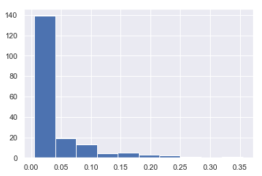

```python
# Plot a histogram of degree centrality
plt.hist(list(nx.degree_centrality(G_book1).values()))
plt.show()
```

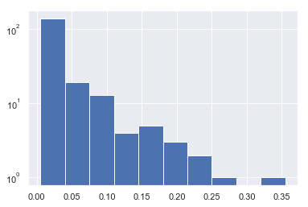

```python
plt.hist(list(nx.degree_centrality(G_book1).values()), log=True)
plt.show()
```

```python
sorted(nx.betweenness_centrality(G_book1).items(), key=lambda x:x[1], reverse=True)[0:10]
```

```
[('Eddard-Stark', 0.2696038913836117),
 ('Robert-Baratheon', 0.21403028397371796),
 ('Tyrion-Lannister', 0.1902124972697492),
 ('Jon-Snow', 0.17158135899829566),
 ('Catelyn-Stark', 0.1513952715347627),
 ('Daenerys-Targaryen', 0.08627015537511595),
 ('Robb-Stark', 0.07298399629664767),
 ('Drogo', 0.06481224290874964),
 ('Bran-Stark', 0.05579958811784442),
 ('Sansa-Stark', 0.03714483664326785)]
```

#### Evolution of importance of characters over the books

Let's look at the evolution of degree centrality of a couple of characters like Eddard Stark, Jon Snow, Tyrion which showed up in the top 10 of degree centrality in first book.

We create a dataframe with character columns and index as books where every entry is the degree centrality of the character in that particular book and plot the evolution of degree centrality Eddard Stark, Jon Snow and Tyrion. We can see that the importance of Eddard Stark in the network dies off and with Jon Snow there is a drop in the fourth book but a sudden rise in the fifth book

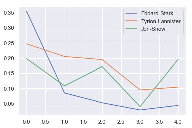

```python
evol = [nx.degree_centrality(book) for book in [G_book1, G_book2, G_book3, G_book4, G_book5]]
evol_df = pd.DataFrame.from_records(evol).fillna(0)
evol_df[['Eddard-Stark', 'Tyrion-Lannister', 'Jon-Snow']].plot()
```

```python
set_of_char = set()
for i in range(5):
    set_of_char |= set(list(evol_df.T[i].sort_values(ascending=False)[0:3].index))
set_of_char
```

```
{'Brienne-of-Tarth',
 'Cersei-Lannister',
 'Daenerys-Targaryen',
 'Eddard-Stark',
 'Jaime-Lannister',
 'Joffrey-Baratheon',
 'Jon-Snow',
 'Robert-Baratheon',
 'Stannis-Baratheon',
 'Tyrion-Lannister'}
```

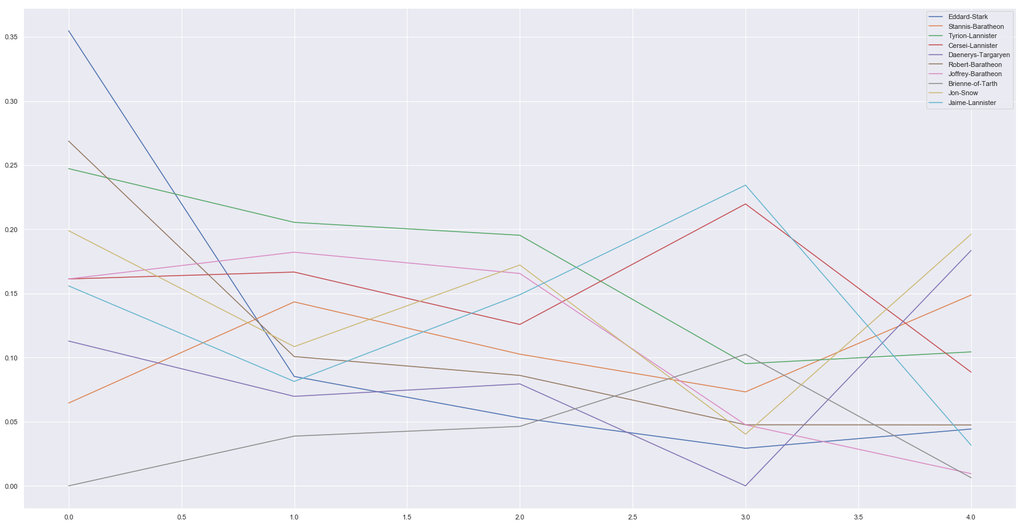

```python
evol_df[list(set_of_char)].plot(figsize=(29,15))
```

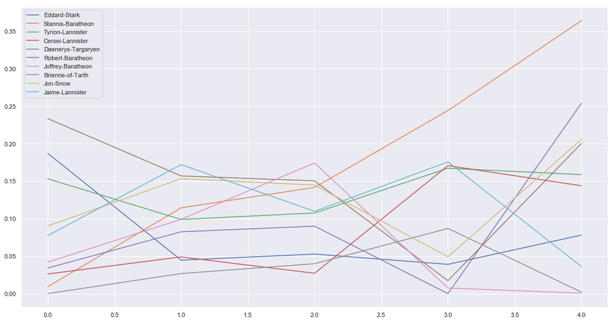

```python
evol = [nx.betweenness_centrality(graph, weight='weight') for graph in [G_book1, G_book2, G_book3, G_book4, G_book5]]
evol_df = pd.DataFrame.from_records(evol).fillna(0)
evol_df[list(set_of_char)].plot(figsize=(19,10))
```

### So what's up with Stannis Baratheon?¶

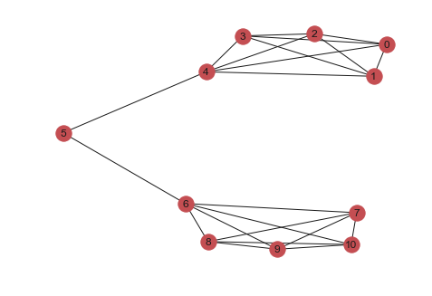

```python
nx.draw(nx.barbell_graph(5, 1), with_labels=True)
```

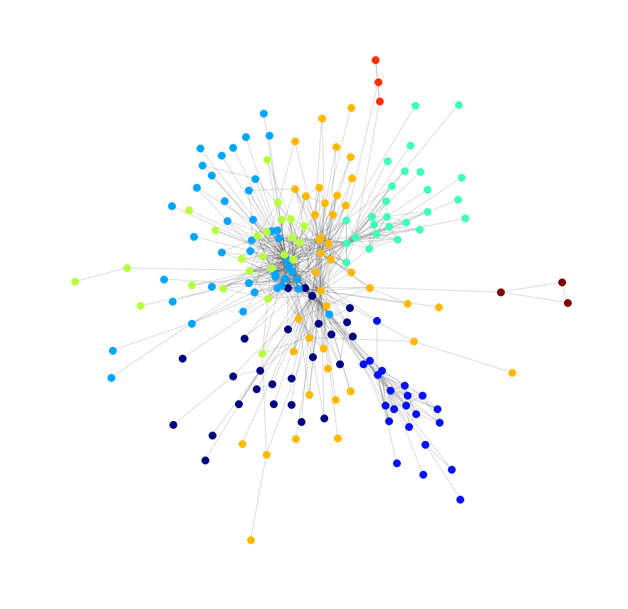

```python
plt.figure(figsize=(15, 15))

partition = community.best_partition(G_book1)
size = (len(set(partition.values())))
pos = nx.spring_layout(G_book1)
count = 0
colors = [cm.jet(x) for x in np.linspace(0, 1, size)]
for com in set(partition.values()):
    list_nodes = [nodes for nodes in partition.keys()
                                if partition[nodes] == com]
    for node in list_nodes:
        G_book1.node[node]['com'] = com
    nx.draw_networkx_nodes(G_book1, pos, list_nodes, node_size = 100, node_color=[colors[count]])
    count = count + 1

nx.draw_networkx_edges(G_book1, pos, alpha=0.2)
plt.axis('off')
plt.show()
```

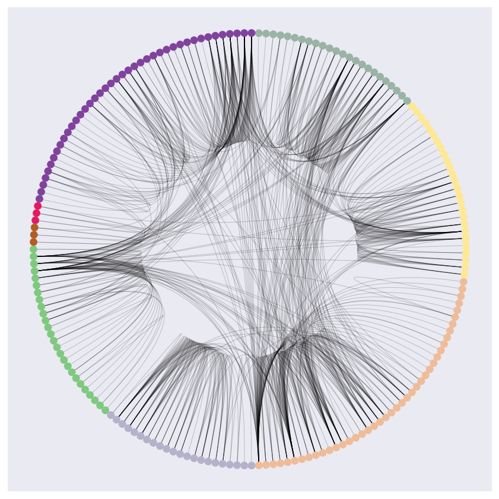

```python
from nxviz import CircosPlot
c = CircosPlot(G_book1, node_color='com', node_grouping='com', figsize=(15, 15))
c.draw()
```

```python
d = {}
for character, par in partition.items():
    if par in d:
        d[par].append(character)
    else:
        d[par] = [character]
```

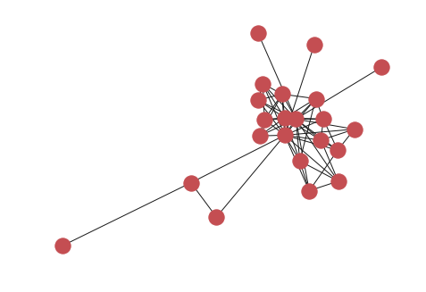

```python
nx.draw(nx.subgraph(G_book1, d[1]))
```

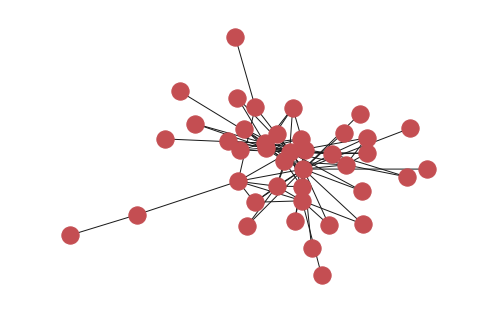

```python
nx.draw(nx.subgraph(G_book1, d[5]))
```

```python
nx.density(G_book1)
```

```
0.03933068828704502
```

```python
nx.density(nx.subgraph(G_book1, d[1]))
```

```
0.2813852813852814
```

## One final game/exercise

Remember the flights dataset we had a look before Game of Thrones.

Suppose we live in a non-capitalistic world and we need to improve air connectivity for the public good.

Can we improve the air connectivity of the US?

```python
US_air_network = nx.from_pandas_dataframe(flights_in_US[flights_in_US.YEAR == 2015], source='ORIGIN', target='DEST',
                                          create_using=nx.DiGraph())
```

```python
US_air_network.number_of_nodes()
```

```
1258
```

```python
US_air_network.number_of_edges()
```

```
25354
```

```python
# nx.average_shortest_path_length(US_air_network)
```

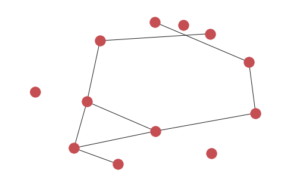

```python
nx.draw_spring(nx.erdos_renyi_graph(12, 0.1, seed=42))
```

```python
[len(i) for i in nx.weakly_connected_components(US_air_network)]
```

```
[1255, 1, 2]
```

```python
list(nx.weakly_connected_components(US_air_network))[1:]
```

```
[{'AIK'}, {'SPB', 'SSB'}]
```

```python
flights_in_US[(flights_in_US.ORIGIN == 'AIK') & (flights_in_US.YEAR == 2015)]
```

|  | YEAR | ORIGIN | DEST | UNIQUE_CARRIER_NAME | PASSENGERS |
| --- | --- | --- | --- | --- | --- |
| 433338 | 2015 | AIK | AIK | {'Wright Air Service'} | 0.0 |

```python
flights_in_US[(flights_in_US.ORIGIN == 'SPB') & (flights_in_US.YEAR == 2015)]
```

|  | YEAR | ORIGIN | DEST | UNIQUE_CARRIER_NAME | PASSENGERS |
| --- | --- | --- | --- | --- | --- |
| 455494 | 2015 | SPB | SSB | {'Seaborne Aviation'} | 26779.0 |

```python
US_air_network.remove_nodes_from(['AIK', 'SPB', 'SSB'])
```

```python
nx.average_shortest_path_length(US_air_network)
```

```
3.028101946281858
```